# U.S. Warehouse Industry and Occupation Indicators

# Classifying warehouse work

There are many types of jobs within warehouses and warehouses can be found in many industries. This makes it challenging to create a snapshot of warehouse work in the U.S. Should we be looking at occupation or industry statistics?

If we look at occupation statistics, we are going to pick up those who perform typical warehouse roles, like stocking, in non-warehouse establishments, like grocery stores. If we look at industry statistics, namely, warehousing, we are going to pick up jobs that aren’t usually carried out warehouses, like sales, and we are going to miss those who work in warehouses that have owners not classified as part of the industry. Amazon is the most notable example of the second problem; it is classified as belonging to the electronic shopping industry.

Several studies provide estimates of who works in warehouses, but they do not go into detail about their classification method.

I propose that we look at the intersection of occupation and industry. In particular, we should look at the most common jobs within the warehousing industry. We should then compare these jobs to what we have observed in our visits to warehouses. Finally, we should look for other industries in which these jobs are common.

The CPS will allow us to look at the industry-occupation intersection for individual workers, over time.

Open questions:

- On the CPS, does industry pertain to the establishment or headquarters of where the employee works? Likely, the answer is ambiguous. The ambiguity is important because we don’t know if the warehouses of retailers, like Sigma, will be classified as belonging to the warehouse or retail industry. It is possible that the OES or QCEW surveys might be less ambiguous. The challenge with this survey is that we can’t look at individual worker characteristics, and I am not sure if we can get historical data. One alternative would be to use the CPS for worker information (e.g., demographics) and for historical trends and the OES or QCEW for a snapshot of employment in the past year.

## Most common occupations in the warehousing and storage industry (NAICS 493)

We can start by looking in the most obvious place: the most common jobs in the warehousing industry. The below table aligns with what we might expect, given our warehouse visits.

| Occupation | Total Employment |
| --- | --- |
| Laborers and Freight, Stock, and Material Movers, Hand | 242,429.30 |
| Packers and Packagers, Hand | 82,448.81 |
| Stock Clerks and Order Fillers | 78,550.55 |
| Industrial Truck and Tractor Operators | 77,076.48 |
| Shipping, Receiving, and Traffic Clerks | 50,942.85 |
| Transportation, Storage, and Distribution Managers | 38,341.37 |
| Other production workers including semiconductor processors and cooling and freezing equipment operators | 33,220.86 |
| Managers, nec (including Postmasters) | 25,775.51 |
| Sales Representatives, Services, All Other | 18,273.64 |
| Inspectors, Testers, Sorters, Samplers, and Weighers | 17,978.25 |

## Selection of occupations

From the above table, we can select occupations to be used in the subsequent analyses. The following occupational SOC codes are included (Census code in italics; pre-2011 SOC codes in parentheses):

- **53-7062**: Laborers and Freight, Stock, and Material Movers, Hand, *9620*
- **53-7064**: Packers and Packagers, Hand, *9640*
- **53-7065**: Stockers and Order Fillers, *5620* (43-5081)
- **53-7051**: Industrial Truck and Tractor Operators, *9600*
- **43-5071**: Shipping, Receiving, and Traffic Clerks, *5610*
- **11-3071**: Transportation, Storage, and Distribution Managers, *0160*

This occupational set is comparable but not identical to other studies of warehouse work, including Gutelius and Theodore (2019) and De Lara (2013).

## Other industries with lots of warehouse jobs

The next question is what other industries should be included? The below tables show industries that have lots of the jobs identified above.

Largest number of workers in most common warehousing occupations

| Industry | Total Employment | Warehousing Occupations Employment |
| --- | --- | --- |
| Grocery stores | 2,598,414.1 | 666,710.5 |
| Warehousing and storage | 830,369.6 | 569,789.4 |
| Department stores and discount stores | 1,975,911.1 | 551,914.8 |
| Couriers and messengers | 963,519.5 | 258,648.1 |
| Electronic shopping | 483,554.3 | 196,335.8 |
| Groceries and related products, merchant wholesalers | 719,332.3 | 159,029.9 |
| Miscellaneous general merchandise stores | 571,493.2 | 147,173.3 |
| Building material and supplies dealers | 1,050,604.6 | 144,611.5 |
| Services incidental to transportation | 768,117.2 | 118,474.2 |
| Truck transportation | 1,588,244.7 | 114,401.8 |

Largest share of workers in most common warehousing occupations

| Industry | Total Employment | Warehousing Occupations Employment | Warehousing Occupation Share |
| --- | --- | --- | --- |
| Warehousing and storage | 830,369.58 | 569,789.36 | 0.69 |
| Tobacco manufacturing | 11,030.06 | 5,851.98 | 0.53 |
| Electronic shopping | 483,554.32 | 196,335.80 | 0.41 |
| Leather tanning and finishing and other allied products manufacturing | 19,250.81 | 7,774.97 | 0.40 |
| Apparel, fabrics, and notions, merchant wholesalers | 124,166.96 | 37,875.80 | 0.31 |
| Fruit and vegetable preserving and specialty food manufacturing | 188,250.57 | 55,968.07 | 0.30 |
| Mail order houses | 88,828.62 | 25,539.20 | 0.29 |
| Department stores and discount stores | 1,975,911.07 | 551,914.81 | 0.28 |
| Furniture and home furnishing, merchant wholesalers | 57,073.31 | 15,515.00 | 0.27 |
| Paper and paper products, merchant wholesalers | 34,140.93 | 9,165.98 | 0.27 |

## Selection of industries

In addition to warehousing, two other industries stand out: electronic shopping and mail order houses. These are what we have in mind when we think of e-commerce and home delivery. I advocate including them. That said, there is reason to have a serious conversation about whether it makes sense to include anyone who performs the most occupations, regardless of industry. If a worker is filling orders, does it matter that they work in the tobacco industry? The following NAICS codes are included:

- **493**: Warehousing and Storage
- **4541**: Electronic Shopping and Mail-Order Houses

# Snapshot of Warehouse employment

## Trend in occupational growth vs U.S. overall

With these occupations and industries in mind, we can look for trends in warehouse work employment.

As of 2019, there were 743,845 people working in warehouse jobs in the U.S. This is up from 159,762 in 2009, after the recession ended.

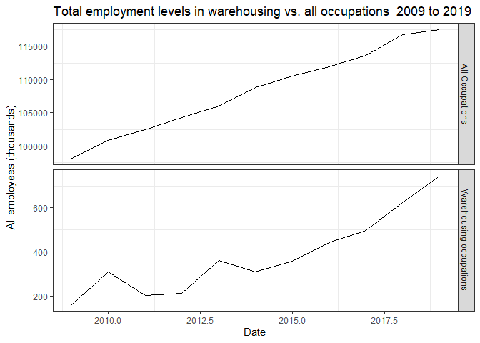

## Annual change in warehouse occupation employment

Relative to the overall economy, warehouse has recently shown outsized growth.

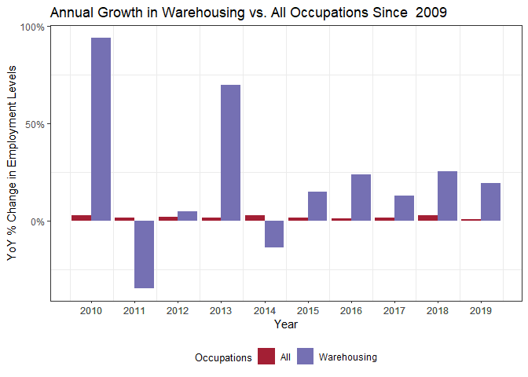

## Share of temp workers

A question that comes up is whether these numbers are overlooking temp workers. Do temp workers make up a sizable share of the warehouse workforce?

In 2019, there were 95,441 people employed in the temp industry (NAICS 5613) who carried out the common warehousing occupations identified above. If we add this number to the above total, 839,286 work in warehousing; 11.37% of them are temps. In what follows, I exclude the temp industry because I am interested in pay and hours, but we could carry about separate analyses on permanent and temp workers.

## Industry employment

We can also look at employment in the warehousing industry (NAICS 493) overall. This will include any jobs, all the way up to management, involved in warehousing.

When we do so, the total number of warehousing jobs comes out to 1,167,000.

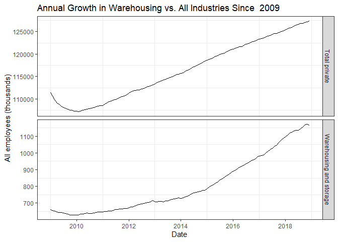

# Warehouse work profile

We can also look at the job characteristics of warehouse work. For these, I continue to focus on the common occupations in the selected industries.

## Full-time vs. part-time

The work is mostly full-time. About 88.12% of employees are engaged in full-time work.

## Wages

A full-time warehouse worker made, on average, about $33,015.65 last year. This number was $15,227.82 for part-time workers.

The average hourly wage for hourly warehouse workers was $17.63.

# Warehouse worker profile

## Sex

Warehouse jobs are mostly male: about 73% are held by men.

## Age

Age profile of common warehousing occupations

| Age Group | Total Employment | Share of Employment |
| --- | --- | --- |
| 16 to 19 | 32215.88 | 0.03 |
| 20 to 24 | 220661.30 | 0.20 |
| 25-54 | 684106.82 | 0.63 |
| 55 to 64 | 122870.90 | 0.11 |
| 65 years and over | 21523.32 | 0.02 |

## Race

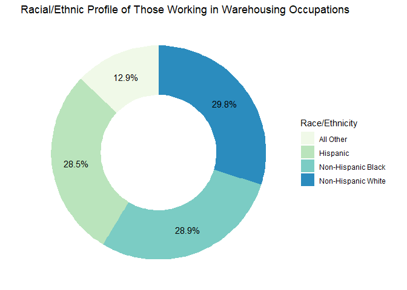

## Education

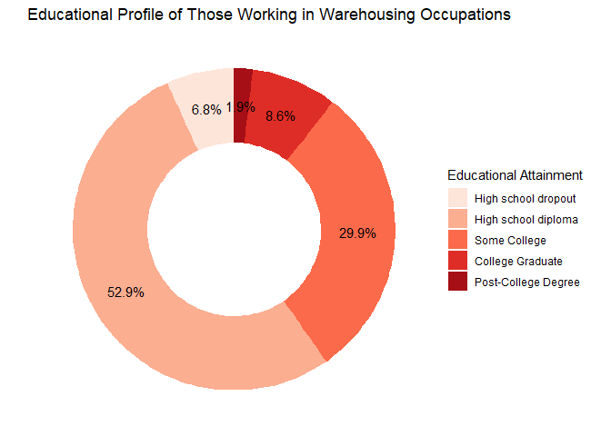

# To dos

There are more topics to investigate, including:

- Establishments
  - Number
  - Location
- Work hours

We can compare these stats to Sigma’s workforce.